# NPV Analysis Report

# Stocking and AAC Summary

The initial total stocking is **766** cords, or **6.1** cords/acre.

The final stocking at **year 20** is **1,252** cords, or **10** cords/acre.

The following table provides a stocking summary at the start of the simulation and the final stocking at the end of the simulation, Year 20.

## Stocking Table

Total Stocking Summary

| Species Group | Year 1 Cords | Year 20 Cords |
| --- | --- | --- |
| Cedar | 42 | 42 |
| Hardwood | 527 | 988 |
| Other Softwood | 10 | 10 |
| Pine | 8 | 8 |
| Poplar | 31 | 42 |
| Spruce-Fir | 148 | 162 |

### Stocking Plots

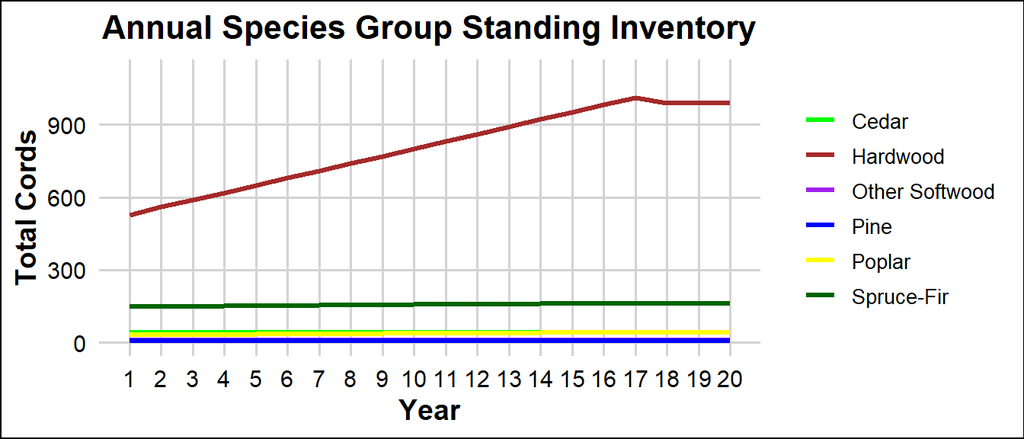

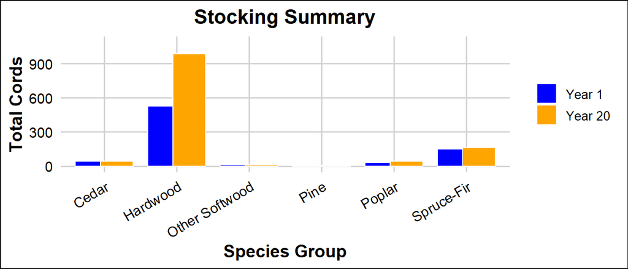

### AAC Plots

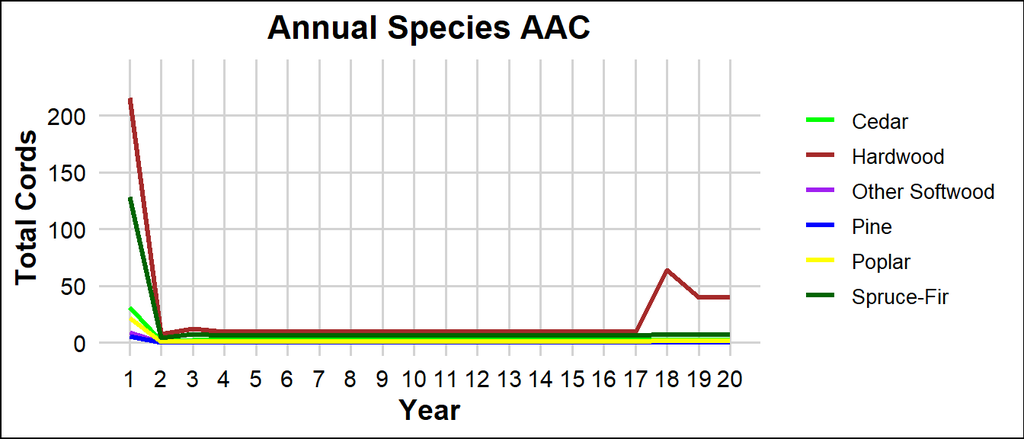

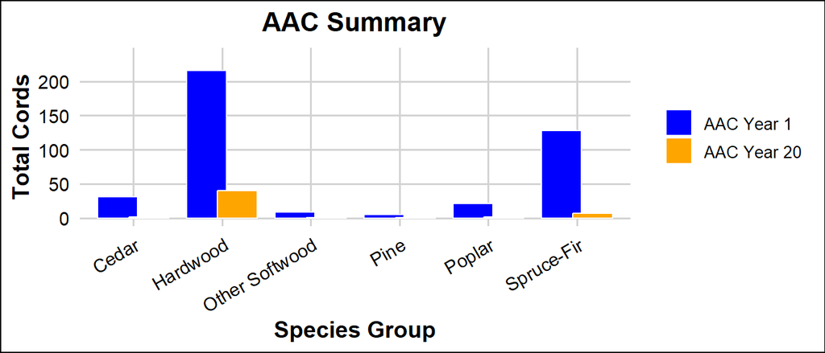